# The Innovation Clock — code, analysis & results in one place

**When do America's most expensive Medicare drugs earn their clinical value — and how does that timing collide with the Inflation Reduction Act's price-negotiation deadline?**

This notebook reproduces the whole analysis end-to-end from cached public data (FDA Drugs@FDA, CMS Medicare spending, CMS negotiation fact sheets, FDA orphan designations). Every section shows the code *and* its output — tables, inline plots, and the results summary.

**The clock (current law, 2026):** a small-molecule drug (FDA **NDA**) can have its Medicare price negotiated starting **year 9** after approval; a biologic (**BLA**) is shielded until **year 13**. That 4-year gap is the contested *"pill penalty."*

## 0 · Setup

```python
import os, sys, json, inspect, datetime as dt
# run from the repo root so `import src...` and the cached data resolve
if os.path.basename(os.getcwd()) == "notebooks":
    os.chdir("..")
sys.path.insert(0, os.getcwd())

import pandas as pd
import matplotlib.pyplot as plt
%matplotlib inline
pd.set_option("display.max_columns", 40)
pd.set_option("display.width", 160)

from src import util, fetch_fda, cohort, analyze

# restrained policy-report palette (matches the dashboard + fact sheet)
C_SM, C_BIO, C_CLOCK, C_AFTER = "#1b6ca8", "#d4761f", "#444444", "#e8b4b8"
color = lambda m: C_BIO if m == "biologic" else C_SM

# load the processed pipeline outputs
master  = pd.read_csv(util.PROCESSED / "innovation_clock_master.csv")
summary = pd.read_csv(util.PROCESSED / "innovation_clock_summary.csv")
payload = json.loads((util.PROCESSED / "dashboard_data.json").read_text())
policy  = json.loads((util.RAW / "policy_facts.json").read_text())

print("master rows :", len(master))
print("summary rows:", len(summary))
print("drugs (json):", len(payload["drugs"]), "| spend year:", payload["spend_year"])
```

```
master rows : 396
summary rows: 64
drugs (json): 64 | spend year: 2023
```

## 1 · The cohort

The cohort is the **union** of (A) the IRA negotiation Cycles 1–3 (40 unique molecules; lists + Maximum Fair Prices are cited constants verified vs CMS/KFF) and (B) the top-50 Medicare Part D drugs by latest-year gross spend.

```python
print("Cohort composition")
print("  unique molecules     :", len(summary))
print("  IRA-negotiated       :", int(summary.in_negotiated.sum()))
print("  in top-50 Part D     :", int(summary.in_top_spend.sum()))
print("  by primary IRA cycle :", summary.dropna(subset=['ira_cycle']).groupby('ira_cycle').size().to_dict())
print("  modality split       :", summary.modality.value_counts(dropna=False).to_dict())

# negotiated drugs with their clock, MFP, and spend
neg = (summary[summary.in_negotiated]
       .assign(spend_B=lambda d: (d.total_medicare_spend_latest_usd/1e9).round(2))
       [["drug_brand","drug_generic","modality","clock_year","ira_cycle","mfp_usd","spend_B","orphan_status"]]
       .sort_values(["ira_cycle","modality","drug_brand"]).reset_index(drop=True))
neg
```

```
Cohort composition
  unique molecules     : 64
  IRA-negotiated       : 40
  in top-50 Part D     : 49
  by primary IRA cycle : {1.0: 10, 2.0: 15, 3.0: 15}
  modality split       : {'small molecule': 43, 'biologic': 19, nan: 2}
```

|  | drug_brand | drug_generic | modality | clock_year | ira_cycle | mfp_usd | spend_B | orphan_status |
| --- | --- | --- | --- | --- | --- | --- | --- | --- |
| 0 | Enbrel | etanercept | biologic | 13.0 | 1.0 | 2355.0 | 2.95 | orphan_approved |
| 1 | NovoLog | insulin aspart | biologic | 13.0 | 1.0 | 119.0 | 2.54 | none |
| 2 | Stelara | ustekinumab | biologic | 13.0 | 1.0 | 4695.0 | 3.02 | orphan_approved |
| 3 | Eliquis | apixaban | small molecule | 9.0 | 1.0 | 231.0 | 18.27 | none |
| 4 | Entresto | sacubitril/valsartan | small molecule | 9.0 | 1.0 | 295.0 | 3.43 | none |
| 5 | Farxiga | dapagliflozin | small molecule | 9.0 | 1.0 | 178.5 | 4.34 | none |
| 6 | Imbruvica | ibrutinib | small molecule | 9.0 | 1.0 | 9319.0 | 2.37 | orphan_approved |
| 7 | Januvia | sitagliptin | small molecule | 9.0 | 1.0 | 113.0 | 4.09 | orphan_approved |
| 8 | Jardiance | empagliflozin | small molecule | 9.0 | 1.0 | 197.0 | 8.84 | none |
| 9 | Xarelto | rivaroxaban | small molecule | 9.0 | 1.0 | 197.0 | 6.31 | none |
| 10 | Austedo | deutetrabenazine | small molecule | 9.0 | 2.0 | 4093.0 | 1.22 | orphan_approved |
| 11 | Breo Ellipta | fluticasone furoate/vilanterol | small molecule | 9.0 | 2.0 | 67.0 | 1.37 | none |
| 12 | Calquence | acalabrutinib | small molecule | 9.0 | 2.0 | 8600.0 | 1.35 | orphan_approved |
| 13 | Ibrance | palbociclib | small molecule | 9.0 | 2.0 | 7871.0 | 2.02 | orphan_approved |
| 14 | Janumet | sitagliptin/metformin | small molecule | 9.0 | 2.0 | 80.0 | 1.19 | orphan_approved |
| 15 | Linzess | linaclotide | small molecule | 9.0 | 2.0 | 136.0 | 1.83 | none |
| 16 | Ofev | nintedanib | small molecule | 9.0 | 2.0 | 6350.0 | 1.84 | orphan_approved |
| 17 | Otezla | apremilast | small molecule | 9.0 | 2.0 | 1650.0 | 0.88 | orphan_approved |
| 18 | Ozempic | semaglutide | small molecule | 9.0 | 2.0 | 274.0 | 10.86 | none |
| 19 | Pomalyst | pomalidomide | small molecule | 9.0 | 2.0 | 8650.0 | 1.71 | orphan_approved |
| 20 | Tradjenta | linagliptin | small molecule | 9.0 | 2.0 | 78.0 | 1.29 | none |
| 21 | Trelegy Ellipta | fluticasone furoate/umeclidinium/vilanterol | small molecule | 9.0 | 2.0 | 175.0 | 4.46 | none |
| 22 | Vraylar | cariprazine | small molecule | 9.0 | 2.0 | 770.0 | 0.94 | none |
| 23 | Xifaxan | rifaximin | small molecule | 9.0 | 2.0 | 1000.0 | 1.09 | orphan_approved |
| 24 | Xtandi | enzalutamide | small molecule | 9.0 | 2.0 | 7004.0 | 2.60 | none |
| 25 | Botox | onabotulinumtoxinA | biologic | 13.0 | 3.0 | NaN | 0.56 | none |
| 26 | Cimzia | certolizumab pegol | biologic | 13.0 | 3.0 | NaN | 0.68 | orphan_approved |
| 27 | Cosentyx | secukinumab | biologic | 13.0 | 3.0 | NaN | 1.19 | orphan_approved |
| 28 | Entyvio | vedolizumab | biologic | 13.0 | 3.0 | NaN | 0.83 | orphan_approved |
| 29 | Orencia | abatacept | biologic | 13.0 | 3.0 | NaN | 1.59 | orphan_approved |
| 30 | Trulicity | dulaglutide | biologic | 13.0 | 3.0 | NaN | 7.36 | none |
| 31 | Xolair | omalizumab | biologic | 13.0 | 3.0 | NaN | 0.67 | none |
| 32 | Anoro Ellipta | umeclidinium/vilanterol | small molecule | 9.0 | 3.0 | NaN | 0.87 | none |
| 33 | Biktarvy | bictegravir/emtricitabine/tenofovir alafenamide | small molecule | 9.0 | 3.0 | NaN | 3.15 | orphan_approved |
| 34 | Erleada | apalutamide | small molecule | 9.0 | 3.0 | NaN | 1.06 | none |
| 35 | Kisqali | ribociclib | small molecule | 9.0 | 3.0 | NaN | 0.37 | orphan_approved |
| 36 | Lenvima | lenvatinib | small molecule | 9.0 | 3.0 | NaN | 0.78 | orphan_approved |
| 37 | Rexulti | brexpiprazole | small molecule | 9.0 | 3.0 | NaN | 0.63 | none |
| 38 | Verzenio | abemaciclib | small molecule | 9.0 | 3.0 | NaN | 0.76 | none |
| 39 | Xeljanz | tofacitinib | small molecule | 9.0 | 3.0 | NaN | 0.87 | none |

## 2 · FDA resolution — the crux

Mapping a brand to the right FDA application is the hard part: openFDA's `openfda` block is empty on many originator NDAs/BLAs, so brand/generic searches *miss the original*. The fix is to search `products.active_ingredients.name`, keep only NDA/BLA originators, anchor **year 0** to the earliest original approval, and read new indications from **efficacy supplements**. Live demo (from cache):

```python
for t in [{"brand":"Eliquis","generic":"apixaban"},
          {"brand":"Imbruvica","generic":"ibrutinib"},
          {"brand":"Enbrel","generic":"etanercept"}]:
    r = fetch_fda.build_drug_record(t)
    print(f"{t['brand']:10s} apps={r['matched_app_numbers']}")
    print(f"           anchor={r['anchor_app']} @ {r['anchor_date']} -> {r['modality']} (clock yr {r['clock_year']}), "
          f"{len(r['events'])} new-indication events")
    print("           first events:", [(str(e['date']), e['years_after_launch']) for e in r['events'][:3]])
print("\nNote: Imbruvica anchors to the 2013 ORIGINAL (NDA205552), not its 2022 reformulation — the reformulation trap the resolver avoids.")
```

```
Eliquis    apps=['NDA202155', 'NDA220073']
           anchor=NDA202155 @ 2012-12-28 -> small molecule (clock yr 9), 3 new-indication events
           first events: [('2014-03-13', 1.2), ('2014-08-21', 1.65), ('2025-04-17', 12.3)]
Imbruvica  apps=['NDA205552', 'NDA210563', 'NDA217003']
           anchor=NDA205552 @ 2013-11-13 -> small molecule (clock yr 9), 13 new-indication events
           first events: [('2014-07-28', 0.7), ('2015-01-29', 1.21), ('2016-03-04', 2.31)]
Enbrel     apps=['BLA103795']
           anchor=BLA103795 @ 1998-11-02 -> biologic (clock yr 13), 17 new-indication events
           first events: [('1999-05-27', 0.56), ('2000-06-06', 1.59), ('2002-01-15', 3.2)]

Note: Imbruvica anchors to the 2013 ORIGINAL (NDA205552), not its 2022 reformulation — the reformulation trap the resolver avoids.
```

```python
# the resolver itself
print(inspect.getsource(fetch_fda.resolve_apps))
```

```
def resolve_apps(drug: Dict[str, Any]) -> List[Dict[str, Any]]:
    """Return the originator (NDA/BLA) application records that belong to ``drug``.

    ``drug`` keys used: brand, generic, optional ``ingredients`` (list of
    normalized tokens) and optional ``manual_apps`` (explicit app numbers).
    """
    brand = drug["brand"]
    generic = drug["generic"]
    expected = frozenset(drug.get("ingredients") or util.ingredient_tokens(generic))

    # Gather candidate application records from several search angles, union by
    # application_number. active_ingredients.name is primary; brand/generic are
    # cheap fallbacks that occasionally surface extra reformulation apps.
    searches: List[str] = []
    for tok in expected:
        searches.append('products.active_ingredients.name:"%s"' % tok)
    searches.append('openfda.brand_name:"%s"' % brand.upper())
    searches.append('openfda.generic_name:"%s"' % generic.upper())
    for app_no in drug.get("manual_apps", []) or []:
        searches.append('application_number:"%s"' % app_no)

    candidates: Dict[str, Dict[str, Any]] = {}
    for expr in searches:
        for res in _search(DRUGSFDA, expr).get("results", []):
            app_no = res.get("application_number", "")
            if app_no and app_no not in candidates:
                candidates[app_no] = res

    manual = set(drug.get("manual_apps", []) or [])
    matched: List[Dict[str, Any]] = []
    for app_no, res in candidates.items():
        if not app_no.startswith(("NDA", "BLA")):
            continue  # drop ANDA generics + others
        if app_no in manual:
            matched.append(res)
            continue
        app_ings = _app_ingredient_set(res)
        # Match when the app's ingredient set EXACTLY equals the drug's expected
        # set, OR the brand matches (covers odd ingredient spellings). Exact
        # equality (not subset) is deliberate and works both directions:
        #   * a combination drug (Entresto = sacubitril+valsartan) must list BOTH
        #     members, so valsartan-only products are excluded; and
        #   * a single-ingredient drug (Jardiance = empagliflozin) does NOT absorb
        #     fixed-dose combinations or co-packs that merely CONTAIN it
        #     (Synjardy, Glyxambi, Trijardy, the Kisqali-Femara co-pack), whose
        #     new indications belong to those distinct products, not to this drug.
        brand_hit = util.normalize_name(brand) in {
            util.normalize_name(b) for b in (res.get("openfda", {}).get("brand_name") or [])
        }
        if (expected and expected == app_ings) or brand_hit:
            matched.append(res)
    return matched
```

## 3 · The processed datasets

`innovation_clock_master.csv` is **long** (one row per drug × indication event); `innovation_clock_summary.csv` is **wide** (one row per drug).

```python
print("MASTER (long) — one row per drug x indication event")
master.head(6)
```

```
MASTER (long) — one row per drug x indication event
```

|  | drug_brand | drug_generic | active_ingredient | fda_application_number | modality | original_approval_date | clock_year | orphan_status | ira_cycle | mfp_usd | part_d_spend_latest_usd | part_b_spend_latest_usd | spend_year | source_urls | indication_event_date | years_after_launch | indication_text | is_after_clock | event_app_number |
| --- | --- | --- | --- | --- | --- | --- | --- | --- | --- | --- | --- | --- | --- | --- | --- | --- | --- | --- | --- |
| 0 | Eliquis | apixaban | APIXABAN | NDA202155 | small molecule | 2012-12-28 | 9.0 | none | 1.0 | 231.0 | 1.827345e+10 | NaN | 2023 | https://www.cms.gov/files/document/fact-sheet-... | 2014-03-13 | 1.20 | 1 INDICATIONS AND USAGE ELIQUIS is a factor Xa... | False | NDA202155 |
| 1 | Eliquis | apixaban | APIXABAN | NDA202155 | small molecule | 2012-12-28 | 9.0 | none | 1.0 | 231.0 | 1.827345e+10 | NaN | 2023 | https://www.cms.gov/files/document/fact-sheet-... | 2014-08-21 | 1.65 | 1 INDICATIONS AND USAGE ELIQUIS is a factor Xa... | False | NDA202155 |
| 2 | Eliquis | apixaban | APIXABAN | NDA202155 | small molecule | 2012-12-28 | 9.0 | none | 1.0 | 231.0 | 1.827345e+10 | NaN | 2023 | https://www.cms.gov/files/document/fact-sheet-... | 2025-04-17 | 12.30 | 1 INDICATIONS AND USAGE ELIQUIS is a factor Xa... | True | NDA202155 |
| 3 | Jardiance | empagliflozin | EMPAGLIFLOZIN | NDA204629 | small molecule | 2014-08-01 | 9.0 | none | 1.0 | 197.0 | 8.839935e+09 | NaN | 2023 | https://www.cms.gov/files/document/fact-sheet-... | 2015-06-26 | 0.90 | 1 INDICATIONS AND USAGE JARDIANCE is indicated... | False | NDA204629 |
| 4 | Jardiance | empagliflozin | EMPAGLIFLOZIN | NDA204629 | small molecule | 2014-08-01 | 9.0 | none | 1.0 | 197.0 | 8.839935e+09 | NaN | 2023 | https://www.cms.gov/files/document/fact-sheet-... | 2016-03-18 | 1.63 | 1 INDICATIONS AND USAGE JARDIANCE is indicated... | False | NDA204629 |
| 5 | Jardiance | empagliflozin | EMPAGLIFLOZIN | NDA204629 | small molecule | 2014-08-01 | 9.0 | none | 1.0 | 197.0 | 8.839935e+09 | NaN | 2023 | https://www.cms.gov/files/document/fact-sheet-... | 2016-12-02 | 2.34 | 1 INDICATIONS AND USAGE JARDIANCE is indicated... | False | NDA204629 |

```python
print("SUMMARY (wide) — one row per drug")
summary.head(6)
```

```
SUMMARY (wide) — one row per drug
```

|  | drug_brand | drug_generic | active_ingredient | fda_application_number | all_app_numbers | modality | clock_year | original_approval_date | ira_cycle | ira_effective_year | mfp_usd | in_negotiated | in_top_spend | cohort_source | part | orphan_status | serial_orphan_candidate | n_orphan_indications_approved | part_d_spend_latest_usd | part_b_spend_latest_usd | total_medicare_spend_latest_usd | spend_year | n_indications_total | n_indications_after_clock | n_indications_in_window | window_lo_yr | window_hi_yr | last_indication_year | source_urls |
| --- | --- | --- | --- | --- | --- | --- | --- | --- | --- | --- | --- | --- | --- | --- | --- | --- | --- | --- | --- | --- | --- | --- | --- | --- | --- | --- | --- | --- | --- |
| 0 | Eliquis | apixaban | APIXABAN | NDA202155 | NDA202155; NDA220073 | small molecule | 9.0 | 2012-12-28 | 1.0 | 2026.0 | 231.0 | True | True | IRA Cycle 1 | Part D | none | False | 0 | 1.827345e+10 | NaN | 1.827345e+10 | 2023 | 3 | 1 | 0 | 7.0 | 9.0 | 2025.0 | https://www.cms.gov/files/document/fact-sheet-... |
| 1 | Jardiance | empagliflozin | EMPAGLIFLOZIN | NDA204629 | NDA204629 | small molecule | 9.0 | 2014-08-01 | 1.0 | 2026.0 | 197.0 | True | True | IRA Cycle 1 | Part D | none | False | 0 | 8.839935e+09 | NaN | 8.839935e+09 | 2023 | 7 | 1 | 3 | 7.0 | 9.0 | 2023.0 | https://www.cms.gov/files/document/fact-sheet-... |
| 2 | Xarelto | rivaroxaban | RIVAROXABAN | NDA022406 | NDA022406; NDA202439; NDA215859 | small molecule | 9.0 | 2011-07-01 | 1.0 | 2026.0 | 197.0 | True | True | IRA Cycle 1 | Part D | none | False | 0 | 6.309247e+09 | NaN | 6.309247e+09 | 2023 | 8 | 1 | 3 | 7.0 | 9.0 | 2021.0 | https://www.cms.gov/files/document/fact-sheet-... |
| 3 | Januvia | sitagliptin | SITAGLIPTIN | NDA021995 | NDA021995; NDA211566; NDA219122 | small molecule | 9.0 | 2006-10-16 | 1.0 | 2026.0 | 113.0 | True | True | IRA Cycle 1 | Part D | orphan_approved | False | 1 | 4.090837e+09 | NaN | 4.090837e+09 | 2023 | 5 | 2 | 0 | 7.0 | 9.0 | 2020.0 | https://www.cms.gov/files/document/fact-sheet-... |
| 4 | Farxiga | dapagliflozin | DAPAGLIFLOZIN | NDA202293 | NDA202293 | small molecule | 9.0 | 2014-01-08 | 1.0 | 2026.0 | 178.5 | True | True | IRA Cycle 1 | Part D | none | False | 0 | 4.342182e+09 | NaN | 4.342182e+09 | 2023 | 8 | 2 | 1 | 7.0 | 9.0 | 2024.0 | https://www.cms.gov/files/document/fact-sheet-... |
| 5 | Entresto | sacubitril/valsartan | SACUBITRIL; VALSARTAN | NDA207620 | NDA207620; NDA218591 | small molecule | 9.0 | 2015-07-07 | 1.0 | 2026.0 | 295.0 | True | True | IRA Cycle 1 | Part D | none | False | 0 | 3.430442e+09 | NaN | 3.430442e+09 | 2023 | 3 | 0 | 1 | 7.0 | 9.0 | 2024.0 | https://www.cms.gov/files/document/fact-sheet-... |

## 4 · Headline analysis

```python
stats = analyze.compute(master, summary)
sm, bio = stats["distribution"]["small molecule"], stats["distribution"]["biologic"]

print(f"Cohort: {stats['n_cohort']} molecules ({stats['n_negotiated']} negotiated) | spend year {stats['spend_year']}")
print(f"Resolved {stats['n_resolved']} / unresolved {stats['n_unresolved']}\n")
print(f"1) Negotiated small molecules gaining an indication in the yr 7-9 window: "
      f"{stats['sm_in_window_count']} of {stats['sm_negotiated']}")
print(f"2) % of new indications approved AFTER the clock: small molecule {sm['pct_after_clock']}%, "
      f"biologic {bio['pct_after_clock']}% (all {stats['pct_all_after_clock']}%)")
print(f"3) Negotiated-cohort Medicare spend: ${stats['negotiated_total_spend']/1e9:.1f}B "
      f"(broader 64-drug union, context only: ${stats['union_total_spend']/1e9:.1f}B)")
print(f"4) Orphan: {stats['negotiated_with_orphan']} negotiated drugs w/ >=1 orphan indication; "
      f"strict serial-orphan = {stats['serial_orphan_strict_count']} {stats['serial_orphan_strict']}")
print(f"5) EPIC 11-yr rule (small molecules only) would block {stats['epic_blocked_count']} of {stats['epic_sm_total']} "
      f"negotiated small molecules (${stats['epic_blocked_spend']/1e9:.1f}B)")

pd.DataFrame([
    {"modality":"small molecule (clock 9)", **sm},
    {"modality":"biologic (clock 13)", **bio},
]).set_index("modality")
```

```
Cohort: 40 molecules (40 negotiated) | spend year 2023
Resolved 40 / unresolved 0

1) Negotiated small molecules gaining an indication in the yr 7-9 window: 20 of 30
2) % of new indications approved AFTER the clock: small molecule 19.2%, biologic 35.6% (all 25.4%)
3) Negotiated-cohort Medicare spend: $112.2B (broader 64-drug union, context only: $156.2B)
4) Orphan: 19 negotiated drugs w/ >=1 orphan indication; strict serial-orphan = 4 ['Calquence', 'Imbruvica', 'Ofev', 'Pomalyst']
5) EPIC 11-yr rule (small molecules only) would block 19 of 30 negotiated small molecules ($67.6B)
```

| modality | n_indications | mean_years | median_years | pct_back_half | pct_after_clock |
| --- | --- | --- | --- | --- | --- |
| small molecule (clock 9) | 167 | 6.01 | 5.84 | 44.3 | 19.2 |
| biologic (clock 13) | 101 | 11.66 | 9.03 | 26.7 | 35.6 |

## 5 · The signature visual — the Innovation Clock

Each lane is an IRA-negotiated drug, from first approval (year 0) to its most recent new indication. Dots are new indications; the diamond is the negotiation clock (yr 9 small molecule / yr 13 biologic); the shaded band is the price-controlled period. Biologics keep earning indications well past where small molecules are already price-controlled.

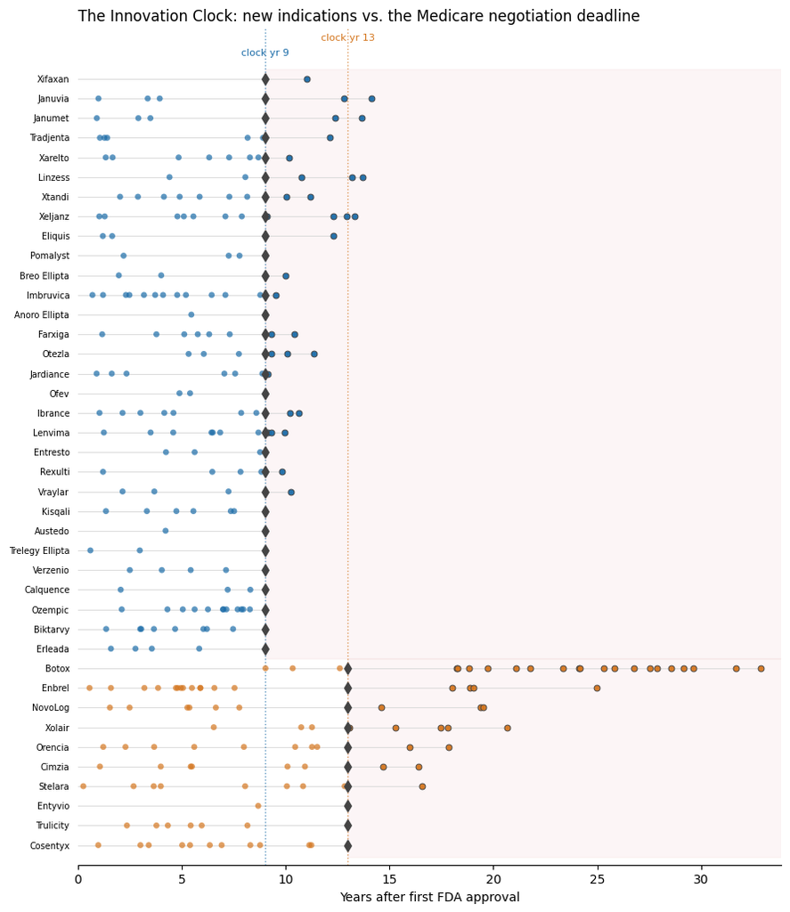

```python
drugs = [d for d in payload["drugs"] if d["modality"] and d["in_negotiated"]]
drugs.sort(key=lambda d: (d["modality"] != "small molecule", d["original_approval_date"]))
yrs = lambda d: [i["years_after_launch"] for i in d["indications"] if i["years_after_launch"] is not None]

n = len(drugs)
fig, ax = plt.subplots(figsize=(9, 0.23*n + 1.2))
xmax = max(max(yrs(d) + [d["clock_year"]]) for d in drugs) + 1  # never clip late indications
n_sm = sum(1 for d in drugs if d["modality"] == "small molecule")
# shade each block's actual price-controlled region (SM from yr 9, biologic from yr 13)
ax.axvspan(9, xmax, ymin=(n - n_sm + 0.5)/(n + 2.6), ymax=(n + 0.5)/(n + 2.6), color=C_AFTER, alpha=0.12)
ax.axvspan(13, xmax, ymin=0.4/(n + 2.6), ymax=(n - n_sm + 0.5)/(n + 2.6), color=C_AFTER, alpha=0.12)
for v, c in [(9, C_SM), (13, C_BIO)]:
    ax.axvline(v, color=c, ls=":", lw=1, alpha=0.7)
for i, d in enumerate(drugs):
    y = n - i
    ax.plot([0, max(yrs(d) + [d["clock_year"]])], [y, y], color="#ddd", lw=0.8, zorder=1)
    for v in yrs(d):
        after = v >= d["clock_year"]
        ax.scatter(v, y, s=24, color=color(d["modality"]),
                   edgecolor=(C_CLOCK if after else "none"), lw=0.7,
                   alpha=0.95 if after else 0.7, zorder=4)
    ax.scatter(d["clock_year"], y, s=42, marker="d", color=C_CLOCK, zorder=5)
    ax.text(-0.4, y, d["brand"], ha="right", va="center", fontsize=7)
ax.text(9, n+1.2, "clock yr 9", color=C_SM, fontsize=8, ha="center")
ax.text(13, n+2.0, "clock yr 13", color=C_BIO, fontsize=8, ha="center")
ax.set(xlim=(0, xmax), ylim=(0, n+2.6), yticks=[], xlabel="Years after first FDA approval")
ax.set_title("The Innovation Clock: new indications vs. the Medicare negotiation deadline", loc="left")
for s in ("top","right","left"): ax.spines[s].set_visible(False)
plt.tight_layout(); plt.show()
```

## 6 · Spend vs. how long a drug keeps earning new indications

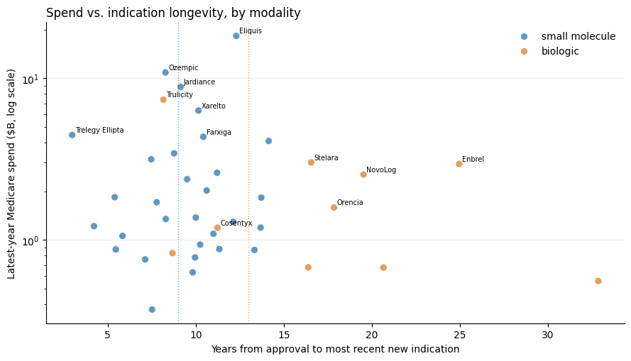

```python
fig, ax = plt.subplots(figsize=(9, 5.2))
for mod, c in (("small molecule", C_SM), ("biologic", C_BIO)):
    pts = [(max(yrs(d) + [0]), d["total_spend"]/1e9, d) for d in payload["drugs"]
           if d["modality"] == mod and d["total_spend"] and d["in_negotiated"]]  # 40 negotiated
    ax.scatter([p[0] for p in pts], [p[1] for p in pts],
               s=[50 if p[2]["in_negotiated"] else 28 for p in pts],
               color=c, alpha=0.7, edgecolor="white", lw=0.6, label=mod)
    for x, yv, d in sorted(pts, key=lambda t: -t[1])[:6]:
        ax.annotate(d["brand"], (x, yv), fontsize=7, xytext=(3,3), textcoords="offset points")
for v, c in [(9, C_SM), (13, C_BIO)]: ax.axvline(v, color=c, ls=":", lw=1, alpha=0.6)
ax.set_yscale("log")
ax.set(xlabel="Years from approval to most recent new indication",
       ylabel="Latest-year Medicare spend ($B, log scale)")
ax.set_title("Spend vs. indication longevity, by modality", loc="left")
ax.legend(frameon=False); ax.grid(axis="y", color="#eee")
for s in ("top","right"): ax.spines[s].set_visible(False)
plt.tight_layout(); plt.show()
```

## 7 · When new indications are approved (distribution)

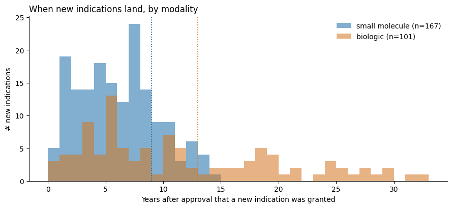

```python
fig, ax = plt.subplots(figsize=(9, 4.2))
all_vals = [v for d in payload["drugs"] if d["modality"] and d["in_negotiated"] for v in yrs(d)]
bins = range(0, int(max(all_vals)) + 2)  # extend past the oldest event so no indication is dropped
for mod, c in (("small molecule", C_SM), ("biologic", C_BIO)):
    vals = [v for d in payload["drugs"] if d["modality"] == mod and d["in_negotiated"] for v in yrs(d)]
    ax.hist(vals, bins=bins, color=c, alpha=0.55, label=f"{mod} (n={len(vals)})")
ax.axvline(9, color=C_SM, ls=":", lw=1.3); ax.axvline(13, color=C_BIO, ls=":", lw=1.3)
ax.set(xlabel="Years after approval that a new indication was granted", ylabel="# new indications")
ax.set_title("When new indications land, by modality", loc="left")
ax.legend(frameon=False)
for s in ("top","right"): ax.spines[s].set_visible(False)
plt.tight_layout(); plt.show()
```

## 8 · Balance check — what an EPIC-style 11-year rule would do

The EPIC Act would push **small-molecule** *selection* from year 7 to year 11. Biologics already sit at year 11, so EPIC cannot remove them — the counterfactual is small-molecule-only. Of the **30 negotiated small molecules**, those < 11 years past approval at selection would become **unreachable** (Public Citizen's published "5 of the first 10, 8 of the next 15" counts all selected drugs; the blocked ones are the small molecules).

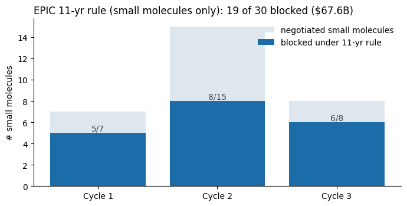

```
Small molecules unreachable under an 11-yr selection rule (years past approval at selection):
```

|  | drug | yrs_at_selection | cycle |
| --- | --- | --- | --- |
| 0 | Ozempic | 7.12 | 2 |
| 1 | Calquence | 7.21 | 2 |
| 2 | Trelegy Ellipta | 7.33 | 2 |
| 3 | Austedo | 7.79 | 2 |
| 4 | Erleada | 7.95 | 3 |
| 5 | Biktarvy | 7.97 | 3 |
| 6 | Entresto | 8.15 | 1 |
| 7 | Verzenio | 8.33 | 3 |
| 8 | Kisqali | 8.88 | 3 |
| 9 | Jardiance | 9.08 | 1 |
| 10 | Vraylar | 9.34 | 2 |
| 11 | Farxiga | 9.64 | 1 |
| 12 | Imbruvica | 9.79 | 1 |
| 13 | Ibrance | 9.95 | 2 |
| 14 | Ofev | 10.26 | 2 |
| 15 | Rexulti | 10.55 | 3 |
| 16 | Eliquis | 10.67 | 1 |
| 17 | Otezla | 10.83 | 2 |
| 18 | Lenvima | 10.95 | 3 |

```python
ebc = {int(k): v for k, v in stats["epic_by_cycle"].items()}
fig, ax = plt.subplots(figsize=(7, 3.6))
cyc = [1, 2, 3]
tot = [ebc[c]["n_sm"] for c in cyc]      # negotiated SMALL MOLECULES per cycle
blk = [ebc[c]["blocked"] for c in cyc]
ax.bar(cyc, tot, color="#dfe7ee", label="negotiated small molecules")
ax.bar(cyc, blk, color=C_SM, label="blocked under 11-yr rule")
for c in cyc:
    ax.text(c, ebc[c]["blocked"]+0.2, f"{ebc[c]['blocked']}/{ebc[c]['n_sm']}", ha="center", fontsize=10, color=C_CLOCK)
ax.set(xticks=cyc, xticklabels=[f"Cycle {c}" for c in cyc], ylabel="# small molecules")
ax.set_title(f"EPIC 11-yr rule (small molecules only): {stats['epic_blocked_count']} of {stats['epic_sm_total']} blocked "
             f"(${stats['epic_blocked_spend']/1e9:.1f}B)", loc="left")
ax.legend(frameon=False)
for s in ("top","right"): ax.spines[s].set_visible(False)
plt.tight_layout(); plt.show()

print("Small molecules unreachable under an 11-yr selection rule (years past approval at selection):")
pd.DataFrame(stats["epic_blocked"], columns=["drug","yrs_at_selection","cycle"])
```

## 9 · Rare-disease (orphan) cut

```python
orph = (summary[summary.in_negotiated & (summary.orphan_status != "none")]
        [["drug_brand","modality","orphan_status","serial_orphan_candidate",
          "n_orphan_indications_approved","ira_cycle"]]
        .sort_values(["serial_orphan_candidate","n_orphan_indications_approved"], ascending=False)
        .reset_index(drop=True))
print(f"Negotiated drugs with >=1 approved orphan indication: {stats['negotiated_with_orphan']}")
print(f"Multi-orphan (>=2 distinct): {stats['negotiated_multi_orphan']}")
print(f"Strict serial-orphan (no non-orphan approval -> OBBBA-exempt): {stats['serial_orphan_strict']}")
orph
```

```
Negotiated drugs with >=1 approved orphan indication: 19
Multi-orphan (>=2 distinct): 12
Strict serial-orphan (no non-orphan approval -> OBBBA-exempt): ['Calquence', 'Imbruvica', 'Ofev', 'Pomalyst']
```

|  | drug_brand | modality | orphan_status | serial_orphan_candidate | n_orphan_indications_approved | ira_cycle |
| --- | --- | --- | --- | --- | --- | --- |
| 0 | Imbruvica | small molecule | orphan_approved | True | 13 | 1.0 |
| 1 | Stelara | biologic | orphan_approved | True | 6 | 1.0 |
| 2 | Lenvima | small molecule | orphan_approved | True | 5 | 3.0 |
| 3 | Pomalyst | small molecule | orphan_approved | True | 4 | 2.0 |
| 4 | Orencia | biologic | orphan_approved | True | 4 | 3.0 |
| 5 | Ofev | small molecule | orphan_approved | True | 3 | 2.0 |
| 6 | Calquence | small molecule | orphan_approved | True | 3 | 2.0 |
| 7 | Entyvio | biologic | orphan_approved | True | 3 | 3.0 |
| 8 | Enbrel | biologic | orphan_approved | True | 2 | 1.0 |
| 9 | Austedo | small molecule | orphan_approved | True | 2 | 2.0 |
| 10 | Xifaxan | small molecule | orphan_approved | True | 2 | 2.0 |
| 11 | Otezla | small molecule | orphan_approved | True | 2 | 2.0 |
| 12 | Januvia | small molecule | orphan_approved | False | 1 | 1.0 |
| 13 | Ibrance | small molecule | orphan_approved | False | 1 | 2.0 |
| 14 | Janumet | small molecule | orphan_approved | False | 1 | 2.0 |
| 15 | Biktarvy | small molecule | orphan_approved | False | 1 | 3.0 |
| 16 | Cimzia | biologic | orphan_approved | False | 1 | 3.0 |
| 17 | Cosentyx | biologic | orphan_approved | False | 1 | 3.0 |
| 18 | Kisqali | small molecule | orphan_approved | False | 1 | 3.0 |

## 10 · Results summary — the data cut both ways

**What the data shows**

- Pills *do* keep earning clinical value as the clock closes — most negotiated small molecules gained a new indication in their yr 7–9 window.
- Biologics keep approving new uses far longer, well past year 13.
- The negotiated cohort is a very large slice of Medicare spending — real, immediate savings at stake.
- An EPIC-style delay would have pulled ~half of these drugs out of negotiation.

**What remains contested**

The same dataset supports both readings — which is exactly why the policy fight is live.

```python
print("CITED POLICY FACTS (both sides) — statement [source]\n")
for f in policy["facts"]:
    print(f"• [{f['topic']}] {f['statement']}")
    print(f"    — {f['source_org']} ({f.get('source_date','')}) {f['source_url']}\n")
```

```
CITED POLICY FACTS (both sides) — statement [source]

• [IRA timing rule (pill penalty)] Under the IRA's Medicare Drug Price Negotiation Program, small-molecule drugs (FDA New Drug Application) become eligible for selection 7 years after approval, with the negotiated maximum fair price (MFP) taking effect at year 9; biologics (Biologics License Applica…
    — Congressional Research Service (2024) https://www.congress.gov/crs-product/R47872

• [Pill penalty (4-year gap)] The four-year difference between when negotiated prices take effect for small molecules (year 9) and biologics (year 13) is commonly called the 'pill penalty'; critics say it creates a structural incentive to develop biologics over small-molecule pills.
    — Epstein Becker Green (2025-05-02) https://www.healthlawadvisor.com/medicare-drug-price-negotiation-program-the-inflation-reduction-act-pill-penalty-and-other-ira-reforms-on-the-horizon-for-2026

• [EPIC Act (H.R. 1492)] The Ensuring Pathways to Innovative Cures (EPIC) Act, H.R. 1492 (119th Congress), would require small-molecule drugs to have at least 11 years of market approval (matching the biologic timeline) before becoming eligible for selection, eliminating the 4-year gap.
    — U.S. Congress (Congress.gov) (2025-02-21) https://www.congress.gov/bill/119th-congress/house-bill/1492

• [EPIC Act status] H.R. 1492 (EPIC Act) was introduced February 21, 2025 by Rep. Greg Murphy (press release Feb 25) with a Senate companion (S. 832, introduced March 4, 2025); as of mid-2026 both remain pending in committee and have not been enacted.
    — Office of Rep. Greg Murphy (2025-02-25) https://murphy.house.gov/media/press-releases/murphy-introduces-legislation-eliminate-ira-pill-penalty-and-improve-small

• [OBBBA orphan provision] The One Big Beautiful Bill Act, signed July 4, 2025, broadened the IRA's orphan-drug exclusion from a single rare-disease indication to drugs whose only approved indication(s) are for one or more rare diseases, so 'serial orphan' drugs with multiple rare-disease indication…
    — Sidley Austin LLP (2025-07-15) https://www.sidley.com/en/insights/newsupdates/2025/07/key-inflation-reduction-act-amendment-broadens-us-protection-for-orphan-drugs

• [OBBBA clock reset] For orphan drugs that later gain a non-orphan approval, the OBBBA resets the negotiation-eligibility clock to begin the day after the first non-orphan approval (not the original FDA approval), substantially delaying negotiation; effective for initial price applicability year 20…
    — Jones Day (2025-07-01) https://www.jonesday.com/en/insights/2025/07/congress-expands-orphan-drug-exemptions-from-medicare-price-negotiations

• [OBBBA orphan cost (CBO)] The Congressional Budget Office's revised estimate (Oct 20, 2025, publication 61818) puts the cost of the OBBBA's expanded orphan-drug exemption at about $8.8 billion over ten years; CBO's original at-enactment estimate was roughly $4.9 billion.
    — Congressional Budget Office (2025-10-20) https://www.cbo.gov/publication/61818

• [Critics: pill penalty is a 'myth'] Public Citizen argues the 'pill penalty' is 'nothing more than a pharma industry myth,' citing research that venture-capital investment in small molecules has not dropped since the negotiation program passed.
    — Public Citizen (2026-04-01) https://www.citizen.org/article/epic-act-would-be-a-multi-billion-dollar-pharma-windfall-at-the-expense-of-seniors/

• [Critics: EPIC would block negotiations] Public Citizen states that had the EPIC Act's delay been in effect, Medicare would have been barred from negotiating 5 of the first 10 drugs (>$37B in annual gross Part D spending) and 8 of the second 15 drugs (>$28B).
    — Public Citizen (2026-04-01) https://www.citizen.org/article/epic-act-would-be-a-multi-billion-dollar-pharma-windfall-at-the-expense-of-seniors/

• [Critics: small-molecule subset] Public Citizen further states that 6 of the 8 (75%) small-molecule drugs selected in 2026 for the third round (Cycle 3 / IPAY 2028) — more than $11B in annual Medicare spending — would have been excluded under an EPIC-style delay.
    — Public Citizen (2026-04-01) https://www.citizen.org/article/epic-act-would-be-a-multi-billion-dollar-pharma-windfall-at-the-expense-of-seniors/

• [Industry (PhRMA) framing] Industry (PhRMA/PHAR, 2023): 61% of the 31 cancer drugs approved 2006-2012 gained at least one new indication after launch, and ~40% of those arrived 7+ years out — inside the window the year-9 clock truncates.
    — PhRMA (Partnership for Health Analytic Research) (2023-06) https://www.prnewswire.com/news-releases/new-analysis-inflation-reduction-act-undermines-cancer-medicine-development-301840713.html

• [Industry projections] A University of Chicago analysis projects roughly 188 fewer small-molecule medicines as a result of the 9-vs-13 gap.
    — University of Chicago analysis (cited via Epstein Becker Green) (2025-05-02) https://www.healthlawadvisor.com/medicare-drug-price-negotiation-program-the-inflation-reduction-act-pill-penalty-and-other-ira-reforms-on-the-horizon-for-2026

• [Independent study (NPC / Patterson 2024)] An independent, peer-reviewed study (Patterson et al., National Pharmaceutical Council, Therapeutic Innovation & Regulatory Science, 2024) found 25% of oncology drugs received their most recent subsequent indication only after they would be negotiation-el…
    — National Pharmaceutical Council (Patterson et al.) (2024) https://www.npcnow.org/resources/ira-may-have-unintended-consequences-subsequent-indications-oncology-drugs-new-research

• [Independent analysis (KFF)] KFF finds that drugs which would be ineligible for negotiation under a delayed (biologic-style) timeline accounted for about two-thirds of total gross Medicare Part D spending on the first 25 selected drugs — $61 billion of $91 billion.
    — KFF (Kaiser Family Foundation) (2024) https://www.kff.org/medicare/the-effect-of-delaying-the-selection-of-small-molecule-drugs-for-medicare-drug-price-negotiation/
```

## 11 · The other deliverables

- **Interactive dashboard:** `dashboard/index.html` (self-contained D3 — pick any drug, or "Compare all").
- **Fact sheet:** `factsheet/factsheet.pdf` (~3 pages, both charts, balanced framing, cited sources).
- **Reproduce everything:** `python -m src.run_all` (offline from cached raw data).

Previews below.

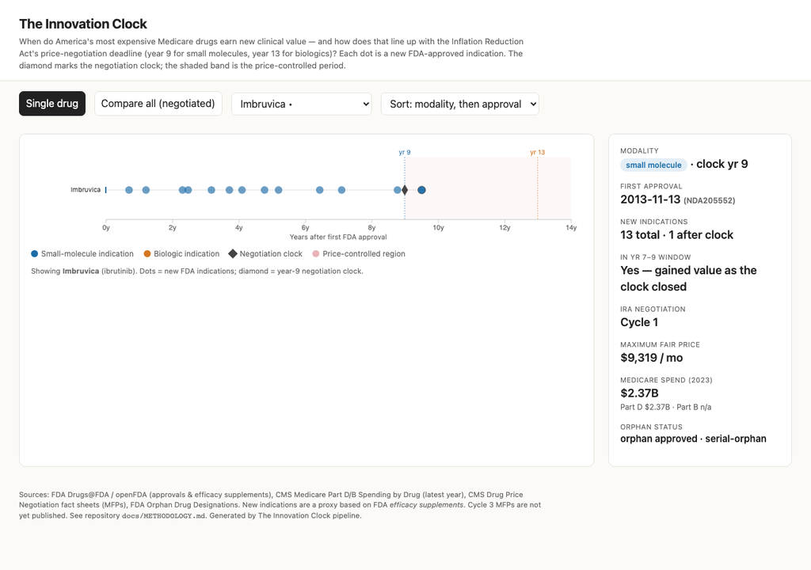

[figure not shown]

```python
from IPython.display import Image, display
for p in ["docs/img/dashboard_single.png", "docs/img/factsheet_p1.png"]:
    if os.path.exists(p):
        display(Image(filename=p, width=760))
```